# Transcriptomic and Pathway Analysis of TNBC and ER+ Breast Cancer

## 6.3 P-value distribution

Last, the distribution of the p-values were revised. In an unbiased situation, there is a peak on low values mixed with a uniform distribution.

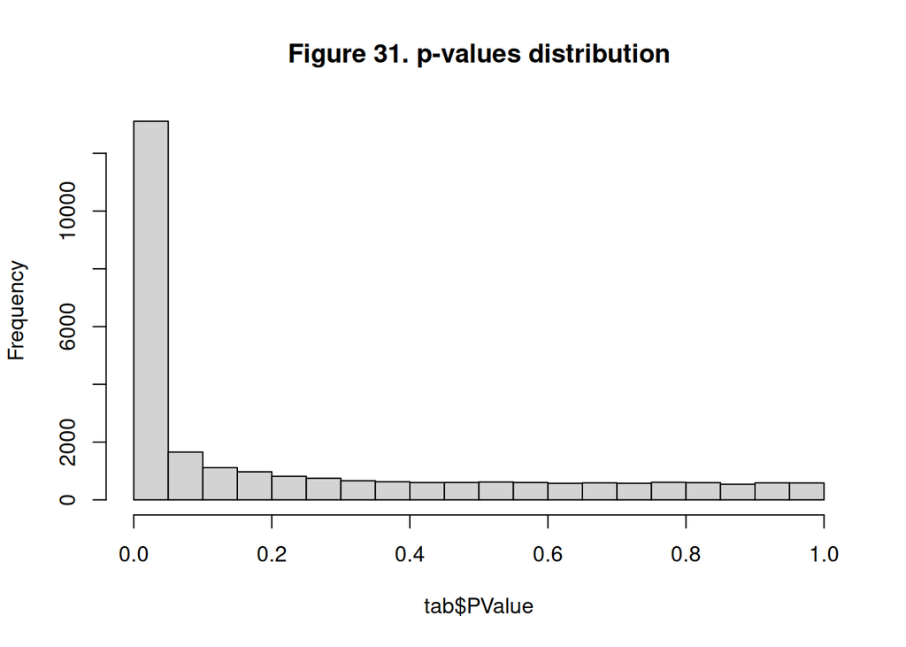

```r
hist(tab$PValue, main="Figure 31. p-values distribution")
```

Figure 31 shows that there is a large peak near 0, meaning many genes have very small p-values and are likely truly differentially expressed. The rest of the p-values are spread roughly uniformly between 0 and 1, which is expected for genes with no real difference. In conclusion, this indicates a good and reliable analysis with real biological signal, not just random noise.

## 6.4 Cluster Analysis

In genomics, cluster analyses are used in the exploratory analysis phase (QC control) and results exploration. It is particularly useful for identifying genes and patients with similar expression profiles.

### 6.4.1 Heatmaps

First, the TMM-normalized matrix with differentially expressed genes were illustrated.

```r
raw_counts <- assay(breastcancer_sel, "raw_counts")
tmm <- cpm(raw_counts, lib.size = lbs_tmm * colSums(raw_counts))

breastcancer_degs <- tmm[names, ]
```

To visualize a heatmap, the pheatmap() function from the *pheatmap* package was used. The scale=“row” option helps interpret the data by centering and scaling each gene—dividing its values by the mean across all patients—so that relative expression patterns are easier to compare.

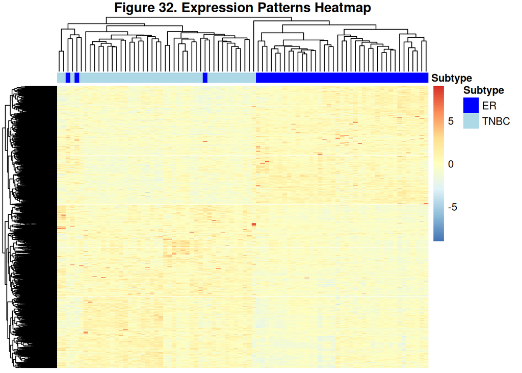

```r
Col <- data.frame(Subtype=breastcancer_sel$group)
rownames(Col) <- colnames(breastcancer_sel)

ann_colors = list(Subtype = c("ER"="blue","TNBC"="lightblue"))

g <- pheatmap(log1p(breastcancer_degs), show_colnames = FALSE, scale = "row", show_rownames = FALSE,
         drop_levels = TRUE, annotation_colors = ann_colors, annotation_col = Col, main = "Figure 32. Expression Patterns Heatmap")
```

Figure 32 shows the expression patterns of differentially expressed genes across all samples (after normalization and scaling). Rows represent genes and columns represent samples, with colors indicating relative expression levels (red = higher, blue = lower compared to the gene’s average). The clustering groups samples with similar expression profiles, and we can see a clear separation between ER and TNBC samples.

In conclusion, the differentially expressed genes successfully distinguish between the two cancer subtypes, confirming strong biological differences in gene expression between ER and TNBC.

### 6.4.2 Silhouette index

The tree was segmented into 2 clusters (i.e., two cancer subtypes groups: ER and TNBC) and computed the distance matrix using the normalized matrix. To evaluate the performance of the clustering the *silhouette index* was used through the silhouette() function from *cluster* package. The silhouette index measures how well each sample fits into its assigned cluster compared to other clusters. For each sample $i$,

$s(i) = \frac{b(i) - a(i)}{\max\{a(i),\, b(i)\}}$,

where $a(i)$ is average distance to all other points in the same cluster and $b(i)$ is average distance to points in the nearest different cluster.

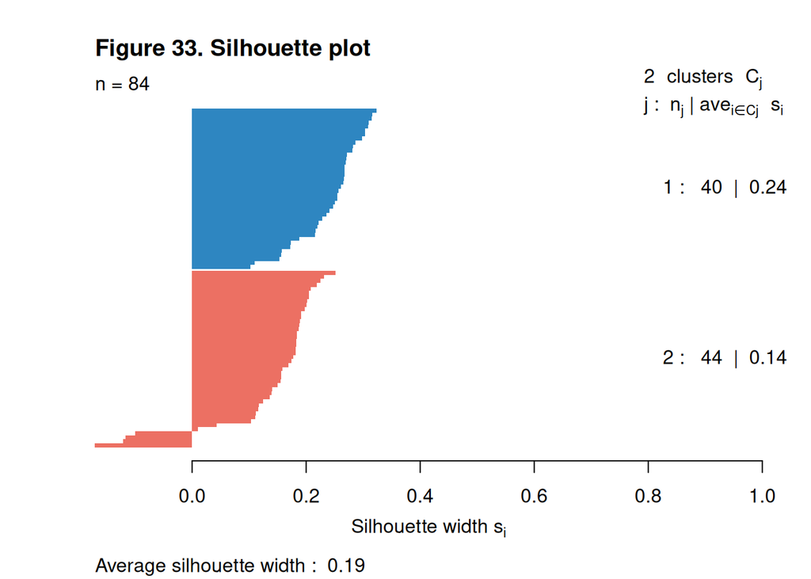

```r
cut <- cutree(g$tree_col, k = 2)

dist_mat <- dist(t(log1p(breastcancer_degs)))
plot(silhouette(cut, dist_mat), col=c("#2E86C1", "#EC7063"), border=NA, main = "Figure 33. Silhouette plot")
```

The silhouette analysis yields a low average value (~0.19), indicating weak clustering. This suggests that TNBC and ER+ samples are not well separated based on their overall gene expression profiles. The observed overlap highlights the shared biological features between these two breast cancer subtypes, despite their known clinical differences. A stronger separation would likely be observed when comparing normal tissue to cancer tissue, where gene expression differences are more pronounced. In this case, both groups represent breast cancer samples, although with differing levels of aggressiveness. Hence, their transcriptional profiles remain relatively similar, resulting in limited clustering separation.

# 7 Gene Enrichment Analysis

For functional enrichment analysis, Ensembl gene identifiers were first converted to Entrez gene identifiers, since annotation databases such as KEGG and Gene Ontology primarily use Entrez IDs for pathway analysis.

```r
# Remove gene version numbers from tab and de objects
rownames(tab) <- sub("\\..*", "", rownames(tab))
rownames(de) <- sub("\\..*", "", rownames(de))

# Extract all gene IDs from the full DE results (all tested genes)
universo <- row.names(tab)

# Extract gene IDs from the significant DEGs to genes of interest
sign <- row.names(de)

# Convert all genes from Ensembl IDs to Entrez IDs using the human annotation database
universo.entrez <- mapIds(org.Hs.eg.db,
                    keys = universo,
                    column = "ENTREZID",
                    keytype = "ENSEMBL")
# Convert DEGs from Ensembl IDs to Entrez IDs
sign.entrez <- mapIds(org.Hs.eg.db,
                    keys = sign,
                    column = "ENTREZID",
                    keytype = "ENSEMBL")
# Convert the mapped IDs to a simple character vector
universo.entrez <- as.character(universo.entrez)

# Convert DEG IDs to character format
sign.entrez <- as.character(sign.entrez)

# Count how many DEGs were successfully mapped to Entrez IDs
length(sign.entrez)
```

```
## [1] 11517
```

```r
# Count how many total genes were successfully mapped to Entrez IDs
length(universo.entrez)
```

```
## [1] 26772
```

The resulting DEG list (sign.entrez) contained 11,517 mapped genes, while the complete background gene list (universo.entrez) contained 26,772 mapped genes. These gene sets were used for downstream enrichment analyses. ORA used only the significant DEGs, whereas GSEA and limma camera used all quantified genes from the complete expression dataset.

## 7.1 KEGG Pathway-Level Enrichment Analysis with limma camera

The first enrichment method applied was the camera function from the limma package, which evaluates pathway enrichment across the full normalized expression matrix rather than only significant DEGs.

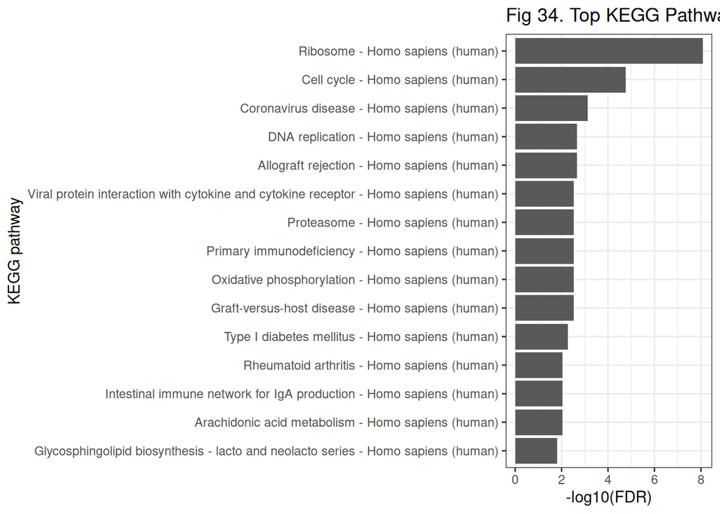

```r
# Extract normalized logCPM values from edgeR object
logCPM_limma <- cpm(dge, log = TRUE, prior.count = 1)

# Remove gene version numbers
rownames(logCPM_limma) <- sub("\\..*", "", rownames(logCPM_limma))

# Match Entrez IDs to the rownames of logCPM_limma
entrez_ids_limma <- universo.entrez[match(rownames(logCPM_limma), universo)]

# Replace row names with Entrez IDs
rownames(logCPM_limma) <- entrez_ids_limma

# Remove genes without Entrez ID
logCPM_limma <- logCPM_limma[!is.na(rownames(logCPM_limma)), ]

# Remove duplicated Entrez IDs
logCPM_limma <- logCPM_limma[!duplicated(rownames(logCPM_limma)), ]

# Download KEGG pathway-gene links for human
kegg_link <- KEGGREST::keggLink("pathway", "hsa")

# Clean KEGG pathway and gene IDs
kegg_pathways <- sub("path:", "", kegg_link)
kegg_genes <- sub("hsa:", "", names(kegg_link))

# Create KEGG gene sets
kegg_sets <- split(kegg_genes, kegg_pathways)

# Run limma camera pathway analysis
camera_results <- camera(
  y = logCPM_limma,
  index = kegg_sets,
  design = design,
  contrast = 2
)

# Add KEGG pathway names
kegg_names <- KEGGREST::keggList("pathway", "hsa")

kegg_names_df <- data.frame(
  Pathway_ID = sub("path:", "", names(kegg_names)),
  Pathway_Name = as.character(kegg_names)
)

camera_results$Pathway_ID <- rownames(camera_results)

camera_results_named <- merge(
  camera_results,
  kegg_names_df,
  by = "Pathway_ID",
  all.x = TRUE
)

# Order results by FDR
camera_results_named <- camera_results_named[order(camera_results_named$FDR), ]

# Select top 15 pathways
top_camera <- camera_results_named[1:15, ]

# Plot top KEGG pathways
ggplot(top_camera, aes(
  x = reorder(Pathway_Name, -log10(FDR)),
  y = -log10(FDR)
)) +
  geom_col() +
  coord_flip() +
  labs(
    title = "Fig 34. Top KEGG Pathways",
    x = "KEGG pathway",
    y = "-log10(FDR)"
  ) +
  theme_bw()
```

The limma camera analysis identified several KEGG pathways whose overall gene expression profiles differed significantly between ER+ and TNBC breast cancer samples. The most significant pathways included Ribosome, Cell Cycle, DNA Replication, Oxidative Phosphorylation, and multiple immune-related pathways, suggesting that protein synthesis, proliferation, metabolism, and immune-associated biological processes contribute to the transcriptional differences observed between the two breast cancer subtypes.

To further understand how these pathways were associated with each breast cancer subtype, a GSEA analysis was performed. This approach allowed us to evaluate whether specific pathways were more strongly enriched in ER+ or TNBC samples.

# 8 GSEA (Gene Set Enrichment Analysis) method

Gene Set Enrichment Analysis (GSEA) was subsequently performed to further investigate whether specific biological pathways were more strongly associated with ER+ or TNBC samples. This method analyzes the complete ranked gene expression dataset rather than focusing only on highly significant genes. Genes are ranked according to a continuous statistical measure, such as log fold-change (logFC), and the analysis evaluates whether genes belonging to a particular pathway tend to accumulate toward the top or bottom of the ranked list more frequently than expected by chance. This approach improves the detection of coordinated biological changes occurring across entire pathways.

```r
# Extract log fold-change (logFC) values for all analyzed genes from the differential expression results table
tt <- tab$logFC

# Assign Entrez gene identifiers as names to each logFC value. This creates the geneID to statistic format required for GSEA
names(tt) <- universo.entrez

# Check for duplicated Entrez gene IDs
table(duplicated(names(tt)))
```

```
##
## FALSE  TRUE
## 26685    87
```

```r
# Remove duplicated gene IDs to retain one value per gene
tt <- tt[!duplicated(names(tt))] # Remove duplicated gene IDs

# Sort genes from highest to lowest logFC values. # Genes at the top are the most upregulated in TNBC relative to ER, while genes at the bottom are the most downregulated
sort_tt <- sort(tt, decreasing = TRUE)

# Print first 10 genes
sort_tt[0:11]
```

```
##      1448      6317      6699      9502    401138     89778      6318    260429
## 10.974735  9.604123  8.439229  8.129550  7.969514  7.895642  7.805527  7.594660
##     54738      4103      5967
##  7.359841  7.255805  7.250335
```

The ranked gene list generated for GSEA contains all analyzed genes ordered according to their log fold-change values. Genes appearing at the top of the ranked list correspond to the most upregulated genes in TNBC relative to ER+ samples, whereas genes at the bottom correspond to the most downregulated genes. This ranked structure serves as the input for GSEA to determine whether genes belonging to specific biological pathways tend to accumulate preferentially among highly upregulated or downregulated genes.

## 8.1 KEGG Pathway with GSEA

Using the ranked gene list generated from the differential expression analysis, Gene Set Enrichment Analysis (GSEA) was performed with the Kyoto Encyclopedia of Genes and Genomes (KEGG) pathway database to identify biological pathways whose genes tend to accumulate among the most upregulated or downregulated genes in the dataset. The analysis was implemented using the gseKEGG() function.

```r
# Run GSEA using the ranked list of all genes (logFC-based)
kk_gsea <- gseKEGG(geneList = sort_tt,
              # Specify human KEGG pathways
              organism = "hsa",

               # Keep only significantly enriched pathways
              pvalueCutoff = 0.05)
```

```
## Reading KEGG annotation online: "https://rest.kegg.jp/link/hsa/pathway"...
```

```
## Reading KEGG annotation online: "https://rest.kegg.jp/list/pathway/hsa"...
```

```r
 # Display top enriched pathways
kk_gsea@result[1:10, 1:7]
```

```
##                ID                                  Description setSize
## hsa04382 hsa04382                 Cornified envelope formation     215
## hsa04672 hsa04672 Intestinal immune network for IgA production      46
## hsa00982 hsa00982            Drug metabolism - cytochrome P450      67
## hsa05332 hsa05332                    Graft-versus-host disease      38
## hsa00053 hsa00053            Ascorbate and aldarate metabolism      29
## hsa00980 hsa00980 Metabolism of xenobiotics by cytochrome P450      73
## hsa05330 hsa05330                          Allograft rejection      35
## hsa05340 hsa05340                     Primary immunodeficiency      37
## hsa04740 hsa04740                       Olfactory transduction     434
## hsa05204 hsa05204        Chemical carcinogenesis - DNA adducts      67
##          enrichmentScore       NES       pvalue     p.adjust
## hsa04382       0.5389435  2.131890 1.000000e-10 1.755000e-08
## hsa04672       0.6620952  2.081863 3.548737e-06 2.491214e-04
## hsa00982      -0.5633296 -2.020268 2.371315e-05 8.323316e-04
## hsa05332       0.6549798  1.980980 6.314087e-05 1.583032e-03
## hsa00053      -0.6746140 -1.979970 9.862631e-05 2.163615e-03
## hsa00980      -0.5524531 -1.976468 1.204250e-05 5.283646e-04
## hsa05330       0.6666882  1.967290 1.053396e-04 2.174954e-03
## hsa05340       0.6549115  1.964389 6.918578e-05 1.618947e-03
## hsa04740      -0.4341618 -1.961714 1.000000e-10 1.755000e-08
## hsa05204      -0.5464814 -1.959845 5.870126e-05 1.583032e-03
```

For clearer interpretation, separate tables were generated for the most significant ER-like and TNBC-like pathways. For visualization purposes, only the top 10 pathways from each group were selected.

```r
library(dplyr)
library(knitr)

# Extract GSEA results
gsea_table <- kk_gsea@result %>%
  as.data.frame() %>%
  dplyr::select(Description, setSize, NES, pvalue, p.adjust) %>%
  dplyr::arrange(p.adjust)

# Top TNBC-enriched pathways (Positive NES)
tnbc_gsea <- gsea_table %>%
  filter(NES > 0) %>%
  dplyr::arrange(desc(NES)) %>%
  head(10)

# Top ER-enriched pathways (Negative NES)
er_gsea <- gsea_table %>%
  filter(NES < 0) %>%
  dplyr::arrange(NES) %>%
  head(10)

# TNBC-associated pathways table
kable(
  tnbc_gsea,
  caption = "Table 1. Top TNBC-Enriched KEGG Pathways from GSEA (Positive NES = TNBC-associated)"
)
```

Table 1. Top TNBC-Enriched KEGG Pathways from GSEA (Positive NES = TNBC-associated)

|  | Description | setSize | NES | pvalue | p.adjust |
| --- | --- | --- | --- | --- | --- |
| hsa04382 | Cornified envelope formation | 215 | 2.131890 | 0.0000000 | 0.0000000 |
| hsa04672 | Intestinal immune network for IgA production | 46 | 2.081863 | 0.0000035 | 0.0002491 |
| hsa05332 | Graft-versus-host disease | 38 | 1.980980 | 0.0000631 | 0.0015830 |
| hsa05330 | Allograft rejection | 35 | 1.967290 | 0.0001053 | 0.0021750 |
| hsa05340 | Primary immunodeficiency | 37 | 1.964389 | 0.0000692 | 0.0016189 |
| hsa05323 | Rheumatoid arthritis | 89 | 1.892871 | 0.0000144 | 0.0005620 |
| hsa04940 | Type I diabetes mellitus | 41 | 1.866176 | 0.0006380 | 0.0086135 |
| hsa04110 | Cell cycle | 158 | 1.864296 | 0.0000086 | 0.0005036 |
| hsa04061 | Viral protein interaction with cytokine and cytokine receptor | 98 | 1.864084 | 0.0000296 | 0.0009455 |
| hsa03010 | Ribosome | 183 | 1.855359 | 0.0000022 | 0.0001931 |

```r
# ER-associated pathways table
kable(
  er_gsea,
  caption = "Table 2. Top ER-Enriched KEGG Pathways from GSEA (Negative NES = ER-associated)"
)
```

Table 2. Top ER-Enriched KEGG Pathways from GSEA (Negative NES = ER-associated)

|  | Description | setSize | NES | pvalue | p.adjust |
| --- | --- | --- | --- | --- | --- |
| hsa00982 | Drug metabolism - cytochrome P450 | 67 | -2.020268 | 0.0000237 | 0.0008323 |
| hsa00053 | Ascorbate and aldarate metabolism | 29 | -1.979971 | 0.0000986 | 0.0021636 |
| hsa00980 | Metabolism of xenobiotics by cytochrome P450 | 73 | -1.976468 | 0.0000120 | 0.0005284 |
| hsa04740 | Olfactory transduction | 434 | -1.961714 | 0.0000000 | 0.0000000 |
| hsa05204 | Chemical carcinogenesis - DNA adducts | 67 | -1.959845 | 0.0000587 | 0.0015830 |
| hsa00040 | Pentose and glucuronate interconversions | 35 | -1.932506 | 0.0002945 | 0.0054406 |
| hsa00830 | Retinol metabolism | 66 | -1.834891 | 0.0003220 | 0.0056516 |
| hsa04927 | Cortisol synthesis and secretion | 65 | -1.820734 | 0.0004068 | 0.0062074 |
| hsa00350 | Tyrosine metabolism | 35 | -1.817484 | 0.0014371 | 0.0180152 |
| hsa05207 | Chemical carcinogenesis - receptor activation | 214 | -1.802534 | 0.0000007 | 0.0000872 |

In addition, a bar plot was generated to visually summarize the top ER-like and TNBC-like pathways presented in Tables 1 and 2.

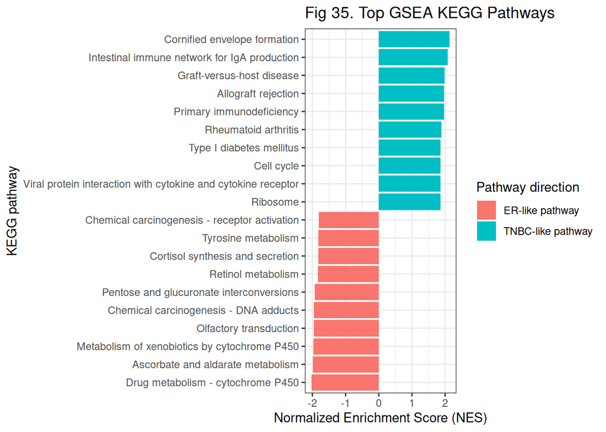

```r
library(dplyr)
library(ggplot2)

# Extract GSEA results
gsea_plot_df <- kk_gsea@result %>%
  as.data.frame() %>%
  dplyr::select(Description, NES, pvalue, p.adjust) %>%
  mutate(
    Direction = ifelse(NES > 0, "TNBC-like pathway", "ER-like pathway")
  )

# Select top 5 TNBC-like and top 5 ER-like pathways
top_gsea_plot <- bind_rows(
  gsea_plot_df %>%
    filter(NES > 0) %>%
    arrange(desc(NES)) %>%
    head(10),

  gsea_plot_df %>%
    filter(NES < 0) %>%
    arrange(NES) %>%
    head(10)
)

# Plot by NES, colored by direction
ggplot(top_gsea_plot,
       aes(x = reorder(Description, NES),
           y = NES,
           fill = Direction)) +
  geom_col() +
  coord_flip() +
  labs(
    title = "Fig 35. Top GSEA KEGG Pathways",
    x = "KEGG pathway",
    y = "Normalized Enrichment Score (NES)",
    fill = "Pathway direction"
  ) +
  theme_bw()
```

The GSEA analysis identified several significantly enriched KEGG pathways across the ranked gene expression dataset. The main result of GSEA is the Normalized Enrichment Score (NES), which indicates both the direction and strength of pathway enrichment. Positive NES values correspond to TNBC-associated pathways, while negative NES values correspond to ER-associated pathways.

Figure 35 summarizes the top enriched pathways identified by GSEA using NES values. Pathways with positive NES values are visualized as TNBC-like pathways, while pathways with negative NES values are visualized as ER-like pathways, allowing clearer comparison of subtype-associated biological processes.

GSEA KEGG analysis showed that TNBC samples were more strongly enriched for pathways related to ribosome activity, cell cycle regulation, and immune-associated signaling, suggesting increased proliferative, protein synthesis, and inflammatory activity compared to ER+ breast cancer samples. In contrast, ER+ pathways were more associated with metabolic and signaling-related biological processes.

## 8.2 GO categories with GSEA

Gene Set Enrichment Analysis (GSEA) was subsequently performed using the Gene Ontology Biological Process (GO-BP) database to further investigate biological functions associated with transcriptomic differences between TNBC and ER+ breast cancer samples. Similar to the KEGG-based GSEA analysis, this approach evaluates enrichment patterns across the complete ranked gene expression dataset rather than only significantly differentially expressed genes. This allows identification of biological processes whose associated genes tend to accumulate among highly upregulated or downregulated genes without requiring a strict DEG significance threshold.

```r
# Run GSEA using the full logFC-ranked gene list against GO Biological Process gene sets
gsea_GO <- gseGO(geneList = sort_tt,
          ont = "BP",
          OrgDb='org.Hs.eg.db',
          keyType = "ENTREZID",
          pAdjustMethod = "BH")

# Store GSEA GO results as a dataframe
gsea_GO_results <- gsea_GO@result

# Display top 10 enriched GO terms with key statistics
# gsea_GO_results
```

The GO-GSEA analysis identified multiple significantly enriched biological processes associated with transcriptomic differences between TNBC and ER+ breast cancer samples. Similar to the KEGG analysis, positively enriched GO terms were associated with TNBC, whereas negatively enriched terms were associated with ER+ breast cancer samples.

To further summarize and directly compare the most strongly enriched GO biological processes, the top positively and negatively enriched terms were selected based on their enrichment scores and visualized in a comparative bar plot (Fig. 36).

[figure not shown]

```r
# Extract GSEA GO results
gsea_GO_plot_df <- gsea_GO@result %>%
  as.data.frame() %>%
  dplyr::select(Description, NES, pvalue, p.adjust) %>%
  mutate(
    Direction = ifelse(NES > 0, "TNBC-like pathway", "ER-like pathway")
  )

# Select top positively and negatively enriched GO terms
top_gsea_GO_plot <- bind_rows(
  gsea_GO_plot_df %>%
    filter(NES > 0) %>%
    arrange(desc(NES)) %>%
    head(10),

  gsea_GO_plot_df %>%
    filter(NES < 0) %>%
    arrange(NES) %>%
    head(10)
)

# Plot GO GSEA results
ggplot(top_gsea_GO_plot,
       aes(x = reorder(Description, NES),
           y = NES,
           fill = Direction)) +
  geom_col() +
  coord_flip() +
  labs(
    title = "Fig 36. Top GSEA GO Biological Process Terms",
    x = "GO Biological Process",
    y = "Normalized Enrichment Score (NES)",
    fill = "Pathway direction"
  ) +
  theme_bw()
```

Figure 36 presents the top enriched GO Biological Process terms identified by GSEA, separated into TNBC-like (positive enrichment) and ER-like (negative enrichment) categories according to their enrichment direction.

# 9 Gene Set Analysis with ORA Method

Over-Representation Analysis (ORA) tests whether a gene set is statistically overrepresented within a list of differentially expressed genes (DEGs) compared to what would be expected by chance, given the size of the background universe.

To identify enriched biological pathways and functional categories within the DEG list, the clusterProfiler package is used through the functions enrichKEGG() for KEGG pathways and enrichGO() for Gene Ontology categories. These enrichment methods implement the Fisher exact test to determine whether specific pathways or biological functions are significantly overrepresented among the DEGs compared to the background gene universe.

## 9.1 KEGG pathways with ORA Method

KEGG pathway enrichment analysis is performed using the Over-Representation Analysis (ORA) method to determine whether the differentially expressed genes (DEGs) are significantly enriched in known biological pathways compared to the complete set of analyzed genes. This analysis identifies pathways containing a higher number of DEGs than expected by chance and returns a table of significantly enriched pathways together with their associated statistical significance values.

Using the Entrez gene identifier vectors generated previously for both the DEG list and the background gene universe, enrichment scores can then be estimated across all available Kyoto Encyclopedia of Genes and Genomes (KEGG) pathways.

```r
# Perform KEGG Over-Representation Analysis (ORA) using significant DEGs
ora_kkeg <- enrichKEGG(gene = sign.entrez,
                       universe = universo.entrez,
                       organism = 'hsa',
                       keyType = 'ncbi-geneid',
                       pvalueCutoff = 0.05,
                       pAdjustMethod = "BH")
```

```
## Reading KEGG annotation online: "https://rest.kegg.jp/conv/ncbi-geneid/hsa"...
```

```r
# View dimensions of enrichment results table
dim(ora_kkeg@result)
```

```
## [1] 352  14
```

```r
# Store KEGG enrichment results as a dataframe
ora_kkeg_results <- ora_kkeg@result

# Order pathways by adjusted p-value (most significant first)
ora_kkeg_results <- ora_kkeg_results[order(ora_kkeg_results$p.adjust), ]

# Table 1. Significantly enriched KEGG pathways identified between TNBC and ER+ breast cancer samples
Table1_KEGG_Pathways <- ora_kkeg_results[, c("Description",
                                             "GeneRatio",
                                             "Count",
                                             "p.adjust",
                                             "geneID")]
# Table1_KEGG_Pathways
```

Several measurements were extracted to evaluate pathway enrichment, including Description, GeneRatio, Count, adjusted p-value (p.adjust), and geneID. Description indicates the name of the enriched KEGG pathway. GeneRatio represents the fraction of differentially expressed genes (DEGs) associated with a given pathway, where higher values indicate greater DEG involvement in that biological process. Count corresponds to the number of DEGs found within the pathway. The adjusted p-value (p.adjust) represents the statistical significance after Benjamini–Hochberg multiple testing correction, with values below 0.05 considered statistically significant. Finally, geneID lists the specific DEGs contributing to the enrichment of each pathway.

To further facilitate interpretation of the KEGG over-representation analysis (ORA) results, several visualization methods were generated using the KEGG pathway annotation database. These plots were used to summarize enriched pathways, visualize pathway significance and DEG involvement, identify shared genes across pathways, and explore relationships among enriched biological processes between TNBC and ER+ breast cancer samples.

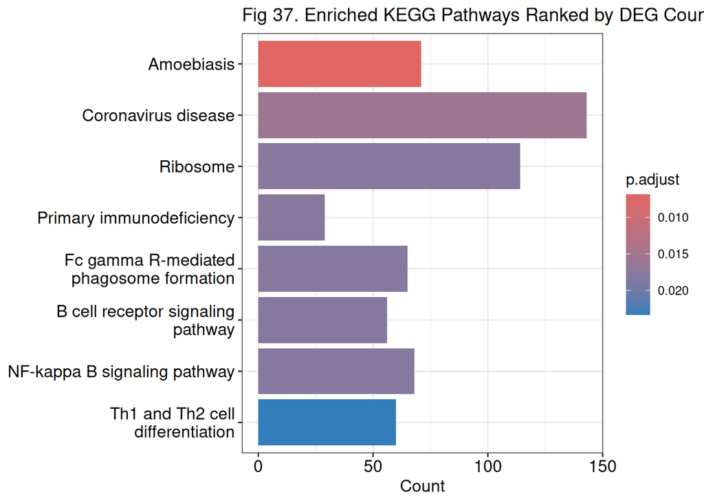

```r
# Fig 37. Barplot of Significantly Enriched KEGG Pathways Ranked by DEG Counts
barplot(ora_kkeg) +
  ggtitle("Fig 37. Enriched KEGG Pathways Ranked by DEG Counts")
```

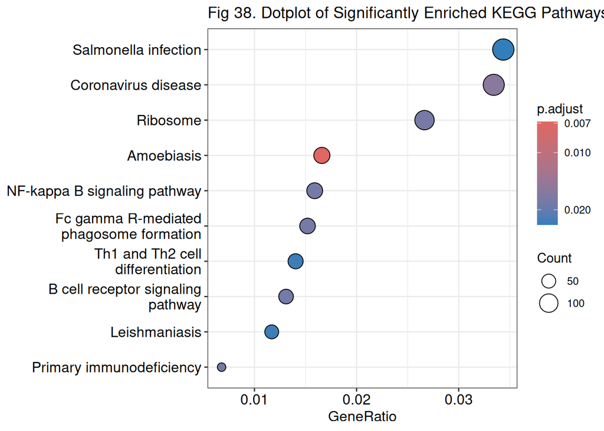

```r
# Fig 38. Dotplot of Significantly Enriched KEGG Pathways
dotplot(ora_kkeg) +
  ggtitle("Fig 38. Dotplot of Significantly Enriched KEGG Pathways")
```

### 9.1.1 KEGG Pathway Visualization and Interpretation Using ORA Results

Among the significantly enriched pathways identified through KEGG over-representation analysis, the NF-kappa B signaling pathway and Ribosome pathway were selected for further visualization and interpretation due to their strong biological relevance to breast cancer. The NF-kappa B signaling pathway is associated with inflammation, immune signaling, tumor progression, and aggressive tumor behavior, while the Ribosome pathway is related to protein synthesis and increased cellular activity commonly observed in rapidly proliferating cancer cells.

These pathways were prioritized because they provide a clearer biological interpretation of the transcriptional differences observed between TNBC and ER+ breast cancer samples compared to broader infection-associated pathways, which likely reflect overlapping immune and inflammatory gene signatures rather than disease-specific mechanisms.

Furthermore, although the original study primarily focused on the identification of recurrent read-through fusion transcripts in breast cancer, several pathways identified in the present analysis, particularly NF-kappa B signaling and immune-related processes, are biologically consistent with mechanisms discussed in the original publication, including inflammatory signaling, cellular proliferation, and cancer-associated cellular activity.

To further investigate the biological relevance of the enriched KEGG pathways, pathway visualization analysis was performed using the pathview package for the NF-kappa B signaling and Ribosome pathways. This approach maps differentially expressed genes (DEGs) directly onto KEGG pathway diagrams, allowing visualization of the specific genes contributing to pathway enrichment and their expression patterns within the biological pathway context.

```r
# Figure 39. NK-kappa B Signaling Pathway
ora_kkeg_results[ora_kkeg_results$ID == "hsa04064", ]
```

```
##                                      category         subcategory       ID
## hsa04064 Environmental Information Processing Signal transduction hsa04064
##                           Description GeneRatio  BgRatio RichFactor
## hsa04064 NF-kappa B signaling pathway   68/4277 103/8712  0.6601942
##          FoldEnrichment   zScore       pvalue   p.adjust      qvalue
## hsa04064       1.344777 3.456507 0.0003629785 0.01825263 0.009609723
##                                                                                                                                                                                                                                                                                                          …
## hsa04064 128178/3553/3654/2919/2921/596/7412/6363/3551/6351/1460/2364…
##          Count
## hsa04064    68
```

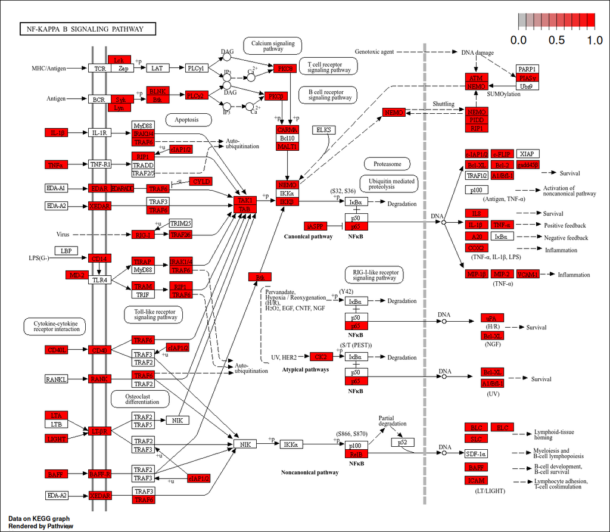

```r
pathview(gene.data = sign.entrez, pathway.id = "hsa04064", species = "hsa")
knitr::include_graphics("hsa04064.pathview.png")
```

```r
# Figure 40. Ribosome Signaling Pathway
ora_kkeg_results[ora_kkeg_results$ID == "hsa03010", ]
```

```
##                                category subcategory       ID Description
## hsa03010 Genetic Information Processing Translation hsa03010    Ribosome
##          GeneRatio  BgRatio RichFactor FoldEnrichment   zScore       pvalue
## hsa03010  114/4277 183/8712  0.6229508       1.268915 3.610336 0.0001934448
##            p.adjust      qvalue
## hsa03010 0.01808094 0.009519327
##                                                                                                                                                                                                                                                                                                          …
## hsa03010 6155/6176/6156/51258/6181/6223/51650/64975/60488/6137/6202/2…
##          Count
## hsa03010   114
```

```r
pathview(gene.data = sign.entrez, pathway.id = "hsa03010", species = "hsa")
```

```
## Info: Working in directory /home/student42/lab_classes/NGS_group_6
```

```
## Info: Writing image file hsa03010.pathview.png
```

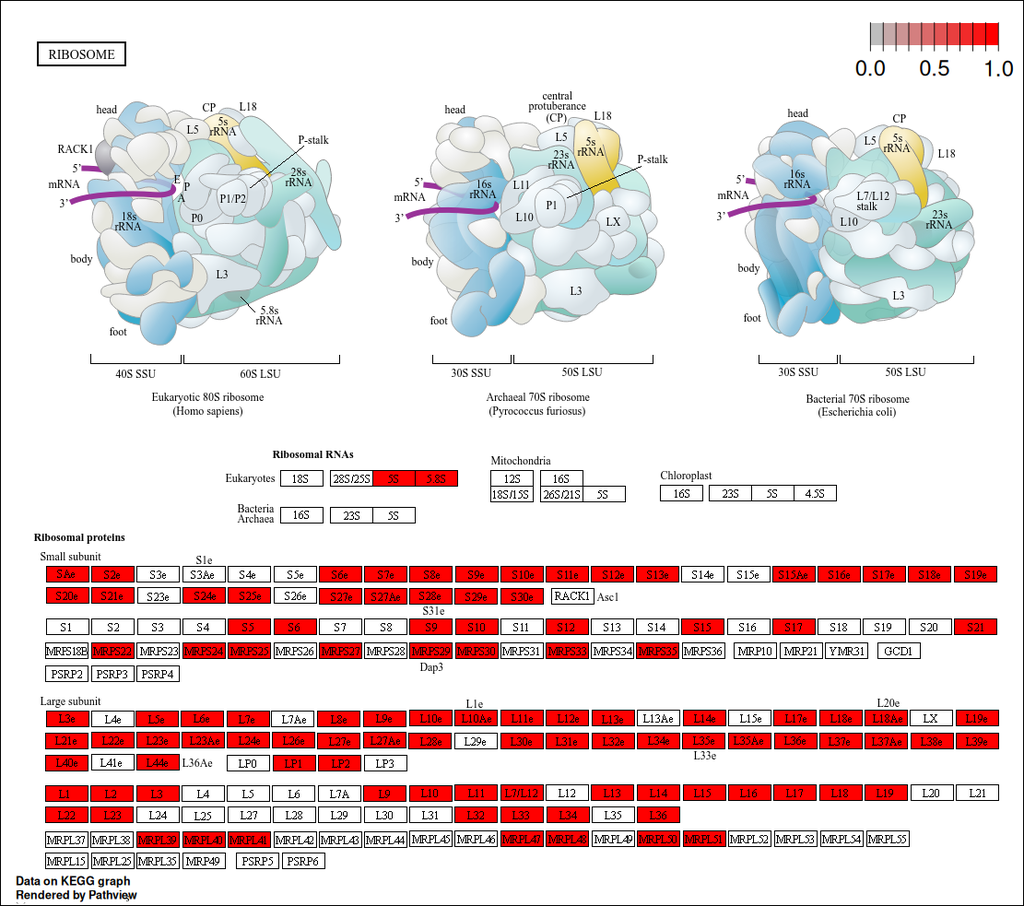

```r
knitr::include_graphics("hsa03010.pathview.png")
```

## 9.2 Gene Ontology categories with ORA Method

Gene Ontology (GO) enrichment analysis was performed using the Over-Representation Analysis (ORA) method to determine whether the differentially expressed genes (DEGs) are significantly enriched in specific biological functions compared to the complete set of analyzed genes. Unlike KEGG and Reactome, which organize genes into discrete biological pathways representing sequences of molecular interactions, GO describes gene attributes across three independent and complementary domains: Biological Process (BP), which captures the broader biological objectives a gene contributes to; Molecular Function (MF), which describes the biochemical activity of the gene product itself; and Cellular Component (CC), which specifies the subcellular location where the gene product operates.

In this analysis, the Biological Process ontology was selected as the primary domain of interest, as it provides the most direct interpretation of transcriptional differences in terms of functional biological activity between TNBC and ER+ breast cancer samples.

```r
# Perform GO Over-Representation Analysis (ORA) using significant DEGs
## Biological Process (BP) ontology selected to capture functional activity differences
ora_go <- enrichGO(gene = sign.entrez,
              universe = universo.entrez,
              OrgDb = 'org.Hs.eg.db',
              keyType = "ENTREZID",
              ont = "BP",
              pvalueCutoff = 0.05,
              pAdjustMethod = "BH",
              readable = TRUE)

# View dimensions of the GO enrichment results table
dim(ora_go@result)
```

```
## [1] 5858   12
```

```r
# Store GO enrichment results as a dataframe
ora_go_results <- ora_go@result

# Order GO terms by adjusted p-value (most significant first)
ora_go_results <- ora_go_results[order(ora_go_results$p.adjust), ]

# Table 2. Significantly enriched GO Biological Process terms identified between TNBC and ER+ breast cancer samples
Table2_GO_BP_Terms <- ora_go_results[, c("Description",
                                          "GeneRatio",
                                          "Count",
                                          "p.adjust",
                                          "geneID")]
# Table2_GO_BP_Terms
```

The Gene Ontology over-representation analysis (GO-ORA) results were summarized using the same statistical framework as KEGG ORA, including enrichment significance, gene overlap, and multiple testing correction. However, unlike pathway-based databases such as KEGG, GO terms describe broader biological functions rather than defined molecular interaction pathways.

To further facilitate interpretation of the GO-ORA results, visualization methods were generated to summarize the most significantly enriched biological processes and to examine gene overlap between enriched GO terms identified in the TNBC versus ER+ breast cancer comparison.

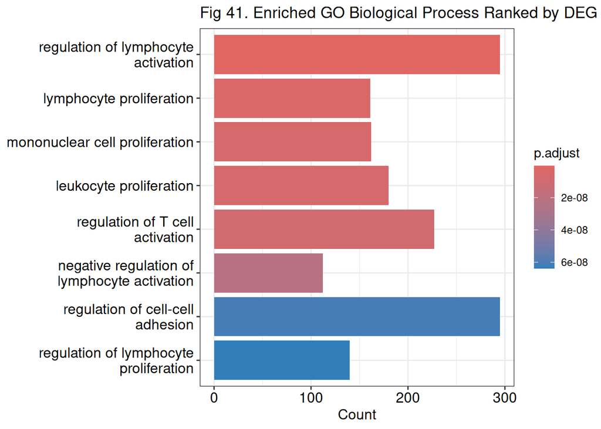

```r
# Fig 41. Enriched GO Ranked by DEG Counts
barplot(ora_go) +
  ggtitle("Fig 41. Enriched GO Biological Process Ranked by DEG Counts")
```

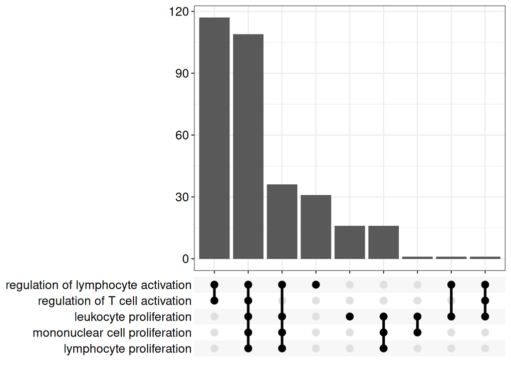

```r
# Fig 42. UpSet Plot of Shared Genes Across GO Biological Processes
upsetplot(ora_go, 5)
```

### 9.2.1 GO Biological Process Interpretation Using ORA Results

GO over-representation analysis (ORA) of differentially expressed genes between TNBC and ER+ breast cancer samples revealed a strong and highly significant enrichment of immune-related biological processes. The most significantly enriched Gene Ontology (GO) terms were predominantly associated with adaptive immune system activity, lymphocyte regulation, and immune cell proliferation and differentiation.

Furthermore, terms related to immune cell interaction and signaling, such as leukocyte cell-cell adhesion (GO:0007159) and immune response–regulating receptor signaling pathways (GO:0002768), were also significantly enriched. These findings suggest enhanced immune cell communication and signaling activity within the tumor microenvironment.

Overall, GO enrichment analysis indicates that the primary biological difference between TNBC and ER+ breast cancer samples is characterized by strong modulation of adaptive immune responses, particularly involving T cell activation, differentiation, and proliferation processes.

# 10 Comparative Analysis with the Original Study Findings

To investigate whether genes involved in the recurrent fusion transcripts reported in the original study were also differentially expressed in the present analysis, Ensembl gene identifiers from the differential expression results table were converted to gene symbols using the org.Hs.eg.db annotation database. This step was necessary because the differential expression results were stored using Ensembl IDs as row names, whereas the genes of interest from the original publication were reported using gene symbols.

```r
# Convert Ensembl gene identifiers stored as row names into gene symbols and add them as a new column called SYMBOL in the DEG table
de$SYMBOL <- mapIds(org.Hs.eg.db,

                    # Use the Ensembl IDs from the row names of the DEG table
                    keys = rownames(de),

                    # Retrieve the official gene symbol annotation
                    column = "SYMBOL",

                    # Specify that the current IDs are Ensembl gene IDs
                    keytype = "ENSEMBL",

                    # If multiple mappings exist, keep only the first match
                    multiVals = "first")
# Display the first rows of the updated DEG table
head(de)
```

```
##                     logFC   logCPM       LR       PValue          FDR    SYMBOL
## ENSG00000143412 -3.049743 4.938860 233.1116 1.249634e-52 3.345520e-48     ANXA9
## ENSG00000176597  3.077512 3.533030 196.5106 1.205982e-44 1.614327e-40    B3GNT5
## ENSG00000134830 -3.279182 3.892917 185.3401 3.307941e-42 2.952006e-38     C5AR2
## ENSG00000248360 -4.780496 4.412170 170.5959 5.483017e-39 3.669783e-35 LINC00504
## ENSG00000109436 -3.274284 7.046147 168.2959 1.743267e-38 9.334148e-35    TBC1D9
## ENSG00000170469 -2.599694 2.253211 166.1466 5.138461e-38 2.292781e-34   SPATA24
```

After annotation, the differential expression table was created for the genes SCNN1A, TNFRSF1A, CTSD, and IFITM10, which are associated with the fusion transcripts SCNN1A-TNFRSF1A and CTSD-IFITM10 identified in the original study. This analysis does not detect the fusion transcripts directly, but instead evaluates whether the individual genes involved in those fusion events are differentially expressed between TNBC and ER+ breast cancer samples.

```r
# Define the genes involved in the fusion transcripts reported in the original publication
fusion_genes <- c("SCNN1A", "TNFRSF1A", "CTSD", "IFITM10")

# Extract rows from the DE table corresponding to the fusion-related genes using the newly added SYMBOL annotation column
fusion_genes_de <- de[de$SYMBOL %in% fusion_genes, ]

# Display the differential expression results for the fusion-associated genes
fusion_genes_de
```

```
##                     logFC    logCPM       LR       PValue          FDR  SYMBOL
## ENSG00000111319 -2.823759  7.230510 85.41056 2.424222e-20 3.245063e-18  SCNN1A
## ENSG00000244242 -2.085094  7.881711 25.63067 4.134152e-07 3.454079e-06 IFITM10
## ENSG00000117984 -1.381070 10.780547 23.79715 1.070407e-06 8.031654e-06    CTSD
```

```r
# Create clean table
fusion_table <- fusion_genes_de[, c("SYMBOL", "logFC", "logCPM", "PValue", "FDR")]

# Add Ensembl IDs as a column
fusion_table$Ensembl_ID <- rownames(fusion_table)

# Reorder columns
fusion_table <- fusion_table[, c("Ensembl_ID", "SYMBOL", "logFC", "logCPM", "PValue", "FDR")]

# Format values for report
fusion_table$logFC <- round(fusion_table$logFC, 2)
fusion_table$logCPM <- round(fusion_table$logCPM, 2)
fusion_table$PValue <- format(fusion_table$PValue, scientific = TRUE, digits = 3)
fusion_table$FDR <- format(fusion_table$FDR, scientific = TRUE, digits = 3)

# Create report table
knitr::kable(
  fusion_table,
  caption = "Table 3. Differential Expression Results of Fusion-Associated Genes",
  col.names = c("Ensembl ID", "Gene", "logFC", "logCPM", "P-value", "FDR"),
  align = "c"
)
```

Table 3. Differential Expression Results of Fusion-Associated Genes

|  | Ensembl ID | Gene | logFC | logCPM | P-value | FDR |
| --- | --- | --- | --- | --- | --- | --- |
| ENSG00000111319 | ENSG00000111319 | SCNN1A | -2.82 | 7.23 | 2.42e-20 | 3.25e-18 |
| ENSG00000244242 | ENSG00000244242 | IFITM10 | -2.09 | 7.88 | 4.13e-07 | 3.45e-06 |
| ENSG00000117984 | ENSG00000117984 | CTSD | -1.38 | 10.78 | 1.07e-06 | 8.03e-06 |

The differential expression analysis identified three fusion-associated genes reported in the original study as significantly different between TNBC and ER+ breast cancer samples. SCNN1A, IFITM10, and CTSD showed significant differential expression based on their low FDR values and all presented negative logFC values, indicating lower expression in TNBC relative to ER+ samples. Among these genes, SCNN1A showed the strongest differential expression signal. In contrast, TNFRSF1A was not identified as significantly differentially expressed under the selected filtering criteria.

The absence of significant differential expression for TNFRSF1A may be related to the structure of the fusion transcripts described in the original study, where SCNN1A frequently appeared as the primary fusion partner fused to TNFRSF1A. Consequently, the expression signal may be more strongly associated with SCNN1A than with TNFRSF1A itself (Figure 1; Varley et al., 2014).

Additionally, a logFC plot was generated to further evaluate whether the fusion-associated genes showed expression patterns more characteristic of ER+ or TNBC samples.

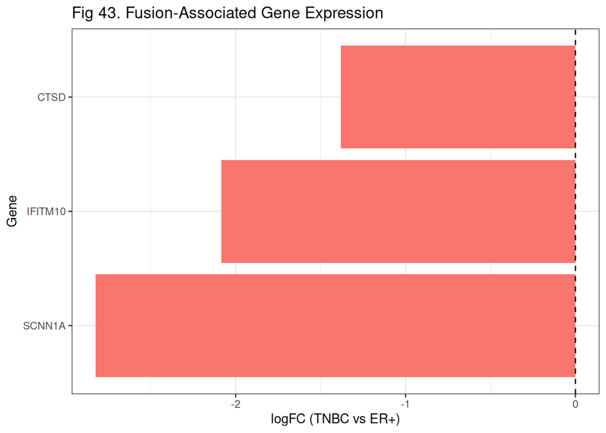

```r
# Horizontal diverging bar plot for fusion-associated genes
ggplot(fusion_genes_de,
       aes(x = reorder(SYMBOL, logFC),
           y = logFC,
           fill = logFC > 0)) +

  geom_col() +

  coord_flip() +

  geom_hline(yintercept = 0,
             linetype = "dashed",
             color = "black") +

  labs(
    title = "Fig 43. Fusion-Associated Gene Expression",
    x = "Gene",
    y = "logFC (TNBC vs ER+)"
  ) +

  theme_bw() +

  theme(legend.position = "none")
```

Although pathway-level analyses suggested stronger enrichment of proliferation, ribosome, and immune-associated biological processes in TNBC samples, several individual fusion-associated genes identified in the original study, including SCNN1A, IFITM10, and CTSD, showed relatively higher expression in ER+ samples. This indicates that individual fusion-associated genes do not necessarily follow the same overall expression trends observed at the pathway level.

## 10.1 KEGG Pathway Enrichment (ORA) for Genes Identified in Both Studies

Next, the significantly differentially expressed genes (SCNN1A, IFITM10, and CTSD) were analyzed using ORA for KEGG pathway enrichment. ORA uses only the differentially expressed genes to identify enriched biological pathways.

```r
# Convert fusion-associated gene symbols into Entrez IDs because KEGG ORA results use Entrez gene identifiers
fusion_entrez <- mapIds(org.Hs.eg.db,
                        keys = fusion_genes,
                        column = "ENTREZID",
                        keytype = "SYMBOL",
                        multiVals = "first")
# Search enriched KEGG pathways containing the fusion-associated genes
kegg_fusion_matches <- ora_kkeg_results[
  sapply(ora_kkeg_results$geneID, function(x) {
    any(unlist(strsplit(x, "/")) %in% fusion_entrez)
  }),
]

# Extract relevant columns from the matching KEGG pathways
kegg_fusion_matches <- kegg_fusion_matches[, c("Description",
                                               "GeneRatio",
                                               "Count",
                                               "p.adjust",
                                               "geneID")]

# Display enriched KEGG pathways containing fusion-associated genes
kegg_fusion_matches
```

```
##                                        Description GeneRatio Count   p.adjust
## hsa04915                Estrogen signaling pathway   83/4277    83 0.07269552
## hsa05152                              Tuberculosis   99/4277    99 0.13414463
## hsa04140                        Autophagy - animal   92/4277    92 0.20771077
## hsa04960 Aldosterone-regulated sodium reabsorption   23/4277    23 0.24404027
## hsa04210                                 Apoptosis   75/4277    75 0.24404027
## hsa05415                   Diabetic cardiomyopathy  103/4277   103 0.25504043
## hsa04071            Sphingolipid signaling pathway   65/4277    65 0.46196571
## hsa04142                       Lysosome biogenesis  127/4277   127 0.46286853
## hsa04742                        Taste transduction   34/4277    34 0.98665710
##                                                                                                                                                                                                                                                                                                          …
## hsa04915                                                                                                                                                                                                                                                                                                 …
## hsa05152                                                                                                                                                                                                                     23545/3606/163688/56848/718/8772/3553/64127/8877/3654/4360/5…
## hsa04140                                                                                                                                                                                                                     64689/9706/23001/118471/6794/64798/5595/203228/596/8417/1509…
## hsa04960                                                                                                                                                                                                                                                                                                 …
## hsa04210                                                                                                                                                                                                                                                                                                 …
## hsa05415                                                                                                                                                                                              1535/5160/5166/5880/5465/125965/4711/1536/6392/1509/5293/597…
## hsa04071                                                                                                                                                                                                                                                                                                 …
## hsa04142 23545/155066/4864/151556/1075/10717/219931/729991/64798/535/…
## hsa04742                                                                                                                                                                                                                                                                                                 …
```

```r
# Create clean KEGG fusion pathway table
fusion_pathway_table <- kegg_fusion_matches[, c("Description",
                                                "GeneRatio",
                                                "Count",
                                                "p.adjust")]

# Round adjusted p-values for readability
fusion_pathway_table$p.adjust <- signif(fusion_pathway_table$p.adjust, 3)

# Create formatted report table
library(kableExtra)

fusion_pathway_table %>%
  knitr::kable(
    caption = "Table 4. KEGG Pathways Containing Fusion-Associated Genes",
    col.names = c("KEGG Pathway",
                  "Gene Ratio",
                  "Gene Count",
                  "Adjusted P-value"),
    align = "c",
    booktabs = TRUE
  ) %>%
  kableExtra::kable_styling(
    full_width = FALSE,
    position = "center",
    bootstrap_options = c("striped", "hover", "condensed")
  )
```

Table 4. KEGG Pathways Containing Fusion-Associated Genes

|  | KEGG Pathway | Gene Ratio | Gene Count | Adjusted P-value |
| --- | --- | --- | --- | --- |
| hsa04915 | Estrogen signaling pathway | 83/4277 | 83 | 0.0727 |
| hsa05152 | Tuberculosis | 99/4277 | 99 | 0.1340 |
| hsa04140 | Autophagy - animal | 92/4277 | 92 | 0.2080 |
| hsa04960 | Aldosterone-regulated sodium reabsorption | 23/4277 | 23 | 0.2440 |
| hsa04210 | Apoptosis | 75/4277 | 75 | 0.2440 |
| hsa05415 | Diabetic cardiomyopathy | 103/4277 | 103 | 0.2550 |
| hsa04071 | Sphingolipid signaling pathway | 65/4277 | 65 | 0.4620 |
| hsa04142 | Lysosome biogenesis | 127/4277 | 127 | 0.4630 |
| hsa04742 | Taste transduction | 34/4277 | 34 | 0.9870 |

The fusion-associated genes were linked to several cancer-related KEGG pathways, including Estrogen signaling, Autophagy, Apoptosis, and Sphingolipid signaling. However, unlike the broader enrichment analyses performed using the full transcriptomic dataset, these pathways did not remain statistically significant after multiple testing correction. This suggests that the fusion-associated genes may have more limited pathway-level enrichment when analyzed individually and may be biologically more relevant at the fusion transcript level rather than as independent genes.

## 10.2 GO Pathway Enrichment (ORA) for Genes Identified in Both Studies

To further investigate whether genes involved in the recurrent fusion transcripts reported in the original study also contributed to enriched biological functions identified in the present analysis, the same fusion-associated genes examined in the KEGG analysis — SCNN1A, TNFRSF1A, CTSD, and IFITM10 — were searched within the significantly enriched GO Biological Process terms.

Unlike the KEGG ORA results, which required Entrez gene identifiers for the search, the GO ORA results store gene symbols directly in the geneID column due to readable = TRUE being set during enrichGO(). Therefore, the search was performed using gene symbols directly, without requiring an additional identifier conversion step.

```r
# Search enriched GO Biological Processes containing
# fusion-associated genes identified in the original paper

go_fusion_matches <- ora_go_results[
  sapply(ora_go_results$geneID, function(x) {
    any(fusion_genes %in% unlist(strsplit(x, "/")))
  }),
]

# Extract relevant GO columns
go_fusion_matches <- go_fusion_matches[, c("Description",
                                           "GeneRatio",
                                           "Count",
                                           "p.adjust",
                                           "geneID")]

# Display GO categories containing fusion-associated genes
# go_fusion_matches
```

```r
# Select top 10 GO pathways based on adjusted p-value
go_fusion_table <- go_fusion_matches %>%

  # Sort by adjusted p-value
  arrange(p.adjust) %>%

  # Keep only top 10 pathways
  head(10) %>%

  # Select relevant columns
  dplyr::select(Description,
                GeneRatio,
                Count,
                p.adjust)

# Round adjusted p-values for readability
go_fusion_table$p.adjust <- signif(go_fusion_table$p.adjust, 3)

# Create formatted report table
library(kableExtra)

go_fusion_table %>%
  knitr::kable(
    caption = "Table 5. Top GO Biological Processes Containing Fusion-Associated Genes",
    col.names = c("GO Biological Process",
                  "Gene Ratio",
                  "Gene Count",
                  "Adjusted P-value"),
    align = "c",
    booktabs = TRUE
  ) %>%
  kableExtra::kable_styling(
    full_width = FALSE,
    position = "center",
    bootstrap_options = c("striped", "hover", "condensed")
  )
```

Table 5. Top GO Biological Processes Containing Fusion-Associated Genes

|  | GO Biological Process | Gene Ratio | Gene Count | Adjusted P-value |
| --- | --- | --- | --- | --- |
| GO:0019886 | antigen processing and presentation of exogenous peptide antigen via MHC class II | 20/8752 | 20 | 0.0197 |
| GO:0098739 | import across plasma membrane | 162/8752 | 162 | 0.0239 |
| GO:0002495 | antigen processing and presentation of peptide antigen via MHC class II | 23/8752 | 23 | 0.0250 |
| GO:0043065 | positive regulation of apoptotic process | 268/8752 | 268 | 0.0271 |
| GO:0002504 | antigen processing and presentation of peptide or polysaccharide antigen via MHC class II | 24/8752 | 24 | 0.0311 |
| GO:0097305 | response to alcohol | 144/8752 | 144 | 0.0414 |
| GO:0055080 | monoatomic cation homeostasis | 256/8752 | 256 | 0.0419 |
| GO:0050801 | monoatomic ion homeostasis | 262/8752 | 262 | 0.0431 |
| GO:0098771 | inorganic ion homeostasis | 223/8752 | 223 | 0.0432 |
| GO:0097306 | cellular response to alcohol | 60/8752 | 60 | 0.0630 |

# 11 Conclusion

In conclusion, we analyzed the same dataset used in the original study to investigate the transcriptional differences between Triple Negative Breast Cancer (TNBC) and ER+ breast cancer samples. Exploratory analysis, normalization, differential expression analysis, and multiple enrichment approaches were performed to better understand the biological differences between the two subtypes. The MD plot (Figure 29) and volcano plot (Figure 30) showed clear differential expression patterns between ER+ and TNBC samples, with several genes significantly upregulated or downregulated relative to the ER+ reference group.

The silhouette analysis (Figure 33) showed weak clustering between ER+ and TNBC samples, suggesting that although transcriptional differences exist, the two cancer subtypes still share relatively similar global gene expression profiles. Stronger clustering separation would likely be expected when comparing healthy tissue with cancer tissue rather than comparing two breast cancer subtypes.

Enrichment analyses using limma camera, GSEA, and ORA with KEGG and GO databases consistently identified pathways related to ribosome activity, cell cycle regulation, immune-associated signaling, and inflammatory processes as major contributors to the transcriptomic differences between ER+ and TNBC samples. GSEA further suggested that many of these pathways were more strongly enriched in TNBC samples, indicating increased proliferative, protein synthesis, and immune-related activity compared to ER+ samples.